# Proposal

Andrew Maloney

4/4/2019

*Project Coordinator:* Andrew Maloney *Team Members:* Elaine Oldbear, Connor Hergenreter, Sonya Haan

[** Military Expenditure Data Set **](https://www.sipri.org/databases/milex)

#### This data set contains the military expenditure of every country existing(at the time) in 1949 to 2017.

#### This data set is extremely “flexible,” which makes it easy to work with other data or new data scraped by our team. Our teams goal for this project is to create multiple background maps, choropleth maps, and connection maps to show relationships between military expenditures for each Country and other variables. Also, we will be creating time series charts. Hopefully exploring this in great detail will bring about answers to questions we did not think of at the beginning of this project.

#### Our team also wants to use machine learning algorithms to help predict future trends with our data.

##### This Rmd file also includes a “somewhat” cleaned version of an excel file we are using as a “base” for are project.

```r
library(readxl)
library(dplyr)
```

```r
library(forcats)
library(ggplot2)
library(tidyr)
library(stringr)
library(reshape2)
library(broom)
library(mapproj)
library(sp)
library(maptools)
Expenditure_USD <- read_excel('Military_Expenditure_Data.xlsx', sheet = 'Current USD')  # This sheet has also been cleaned up in excel.  There were multiple imbedded pictures and links, so I removed them before I used R.
head(Expenditure_USD)
```

```
## # A tibble: 6 x 71
##   Country Notes `1949` `1950` `1951` `1952` `1953` `1954` `1955` `1956`
##   <chr>   <chr> <chr>  <chr>  <chr>  <chr>  <chr>  <chr>  <chr>  <chr>
## 1 Africa  <NA>  <NA>   <NA>   <NA>   <NA>   <NA>   <NA>   <NA>   <NA>
## 2 North … <NA>  <NA>   <NA>   <NA>   <NA>   <NA>   <NA>   <NA>   <NA>
## 3 Algeria 1     xxx    xxx    xxx    xxx    xxx    xxx    xxx    xxx
## 4 Libya   ‡ ¶ 2 xxx    xxx    . .    . .    . .    . .    . .    . .
## 5 Morocco 3     xxx    xxx    xxx    xxx    xxx    xxx    xxx    23.71…
## 6 Tunisia <NA>  xxx    xxx    xxx    xxx    xxx    xxx    xxx    3.714…
## # … with 61 more variables: `1957` <chr>, `1958` <chr>, `1959` <chr>,
## #   `1960` <chr>, `1961` <chr>, `1962` <chr>, `1963` <chr>, `1964` <chr>,
## #   `1965` <chr>, `1966` <chr>, `1967` <chr>, `1968` <chr>, `1969` <chr>,
## #   `1970` <chr>, `1971` <chr>, `1972` <chr>, `1973` <chr>, `1974` <chr>,
## #   `1975` <chr>, `1976` <chr>, `1977` <chr>, `1978` <chr>, `1979` <chr>,
## #   `1980` <chr>, `1981` <chr>, `1982` <chr>, `1983` <chr>, `1984` <chr>,
## #   `1985` <chr>, `1986` <chr>, `1987` <chr>, `1988` <chr>, `1989` <chr>,
## #   `1990` <chr>, `1991` <chr>, `1992` <chr>, `1993` <chr>, `1994` <chr>,
## #   `1995` <chr>, `1996` <chr>, `1997` <chr>, `1998` <chr>, `1999` <chr>,
## #   `2000` <chr>, `2001` <chr>, `2002` <chr>, `2003` <chr>, `2004` <chr>,
## #   `2005` <chr>, `2006` <chr>, `2007` <chr>, `2008` <chr>, `2009` <chr>,
## #   `2010` <chr>, `2011` <chr>, `2012` <chr>, `2013` <chr>, `2014` <chr>,
## #   `2015` <chr>, `2016` <chr>, `2017` <chr>
```

```r
str(Expenditure_USD)
```

```
## Classes 'tbl_df', 'tbl' and 'data.frame':    191 obs. of  71 variables:
##  $ Country: chr  "Africa" "North Africa" "Algeria" "Libya" ...
##  $ Notes  : chr  NA NA "1" "‡ ¶ 2" ...
##  $ 1949   : chr  NA NA "xxx" "xxx" ...
##  $ 1950   : chr  NA NA "xxx" "xxx" ...
##  $ 1951   : chr  NA NA "xxx" ". ." ...
##  $ 1952   : chr  NA NA "xxx" ". ." ...
##  $ 1953   : chr  NA NA "xxx" ". ." ...
##  $ 1954   : chr  NA NA "xxx" ". ." ...
##  $ 1955   : chr  NA NA "xxx" ". ." ...
##  $ 1956   : chr  NA NA "xxx" ". ." ...
##  $ 1957   : chr  NA NA "xxx" ". ." ...
##  $ 1958   : chr  NA NA "xxx" ". ." ...
##  $ 1959   : chr  NA NA "xxx" "5.5719977712008912" ...
##  $ 1960   : chr  NA NA "xxx" "5.5719977712008912" ...
```

[output cut: 57 more lines]

```r
Expenditure_USD_V1 <- Expenditure_USD %>% gather(key = Country_Year, value = Numerical_Expenditure, 3:71)
```

```r
Expenditure_USD_V1[Expenditure_USD_V1 == ". ."] <- NA
Expenditure_USD_V1[Expenditure_USD_V1 == "xxx"] <- NA
Expenditure_USD_V1[Expenditure_USD_V1 == "NA"] <- NA
Expenditure_USD_V1
```

```
## # A tibble: 13,179 x 4
##    Country      Notes Country_Year Numerical_Expenditure
##    <chr>        <chr> <chr>        <chr>
##  1 Africa       <NA>  1949         <NA>
##  2 North Africa <NA>  1949         <NA>
##  3 Algeria      1     1949         <NA>
##  4 Libya        ‡ ¶ 2 1949         <NA>
##  5 Morocco      3     1949         <NA>
##  6 Tunisia      <NA>  1949         <NA>
##  7 Sub-Saharan  <NA>  1949         <NA>
##  8 Angola       4     1949         <NA>
##  9 Benin        <NA>  1949         <NA>
## 10 Botswana     <NA>  1949         <NA>
## # … with 13,169 more rows
```

```r
Expenditure_USD_V2 <- Expenditure_USD_V1 %>% select(-Notes) %>% mutate(Country_Year = as.numeric(Country_Year), Numerical_Expenditure = as.numeric(Numerical_Expenditure))
Expenditure_USD_V2
```

```
## # A tibble: 13,179 x 3
##    Country      Country_Year Numerical_Expenditure
##    <chr>               <dbl>                 <dbl>
##  1 Africa               1949                    NA
##  2 North Africa         1949                    NA
##  3 Algeria              1949                    NA
##  4 Libya                1949                    NA
##  5 Morocco              1949                    NA
##  6 Tunisia              1949                    NA
##  7 Sub-Saharan          1949                    NA
##  8 Angola               1949                    NA
##  9 Benin                1949                    NA
## 10 Botswana             1949                    NA
## # … with 13,169 more rows
```

```r
summary(Expenditure_USD_V2$Numerical_Expenditure)
```

```
##    Min. 1st Qu.  Median    Mean 3rd Qu.    Max.    NA's
##       0      53     294    5514    2007  711338    5707
```

```r
table(Expenditure_USD_V2$Country)
```

```
##
##                       Afghanistan                            Africa
##                                69                                69
##                           Albania                           Algeria
##                                69                                69
##                          Americas                            Angola
##                                69                                69
##                         Argentina                           Armenia
##                                69                                69
##                    Asia & Oceania                         Australia
##                                69                                69
##                           Austria                        Azerbaijan
##                                69                                69
##                           Bahrain                        Bangladesh
##                                69                                69
##                           Belarus                           Belgium
##                                69                                69
##                            Belize                             Benin
##                                69                                69
##                           Bolivia                Bosnia-Herzegovina
##                                69                                69
##                          Botswana                            Brazil
##                                69                                69
##                            Brunei                          Bulgaria
##                                69                                69
##                      Burkina Faso                           Burundi
##                                69                                69
##                          Cambodia                          Cameroon
##                                69                                69
##                            Canada                        Cape Verde
##                                69                                69
##              Central African Rep. Central America and the Caribbean
##                                69                                69
##                      Central Asia                    Central Europe
##                                69                                69
##                              Chad                             Chile
##                                69                                69
##                       China, P.R.                          Colombia
##                                69                                69
##                             Congo                  Congo, Dem. Rep.
```

[output cut: 136 more lines]

```
##                                69                                69
##                                UK                           Ukraine
##                                69                                69
##                           Uruguay                               USA
##                                69                                69
##                              USSR                        Uzbekistan
##                                69                                69
##                         Venezuela                          Viet Nam
##                                69                                69
##                    Western Europe                             Yemen
##                                69                                69
##                      Yemen, North               Yugoslavia (former)
##                                69                                69
##                            Zambia                          Zimbabwe
##                                69                                69
```

```r
classifications <- c('North Africa', 'Africa', 'Oceania', 'Europe', 'Central Europe', 'Eastern Europe', 'Western Europe', 'Middle East', 'Sub-Saharan', 'Americas', 'Central America and the Caribbean', '', 'North America', 'Asia & Oceania', 'Central Asia', 'East Asia', 'South Asia', 'South-East Asia') #These are more like "regions" and contain no data at all.  I am removing them.
Expenditure_USD_V3 <- Expenditure_USD_V2 %>% filter(!Country %in% classifications) %>% filter(!is.na(Country))
table(Expenditure_USD_V3$Country)
```

```
##
##          Afghanistan              Albania              Algeria
##                   69                   69                   69
##               Angola            Argentina              Armenia
##                   69                   69                   69
##            Australia              Austria           Azerbaijan
##                   69                   69                   69
##              Bahrain           Bangladesh              Belarus
##                   69                   69                   69
##              Belgium               Belize                Benin
##                   69                   69                   69
##              Bolivia   Bosnia-Herzegovina             Botswana
##                   69                   69                   69
##               Brazil               Brunei             Bulgaria
##                   69                   69                   69
##         Burkina Faso              Burundi             Cambodia
##                   69                   69                   69
##             Cameroon               Canada           Cape Verde
##                   69                   69                   69
## Central African Rep.                 Chad                Chile
##                   69                   69                   69
##          China, P.R.             Colombia                Congo
##                   69                   69                   69
##     Congo, Dem. Rep.           Costa Rica        Côte d’Ivoire
##                   69                   69                   69
##              Croatia                 Cuba               Cyprus
##                   69                   69                   69
##           Czech Rep.       Czechoslovakia              Denmark
##                   69                   69                   69
##             Djibouti       Dominican Rep.              Ecuador
##                   69                   69                   69
##                Egypt          El Salvador    Equatorial Guinea
##                   69                   69                   69
##              Eritrea              Estonia             Ethiopia
##                   69                   69                   69
##                 Fiji              Finland               France
##                   69                   69                   69
##                Gabon               Gambia              Georgia
##                   69                   69                   69
##            German DR              Germany                Ghana
```

[output cut: 62 more lines]

```
##                   69                   69                   69
##                 Togo    Trinidad & Tobago              Tunisia
##                   69                   69                   69
##               Turkey         Turkmenistan                  UAE
##                   69                   69                   69
##               Uganda                   UK              Ukraine
##                   69                   69                   69
##              Uruguay                  USA                 USSR
##                   69                   69                   69
##           Uzbekistan            Venezuela             Viet Nam
##                   69                   69                   69
##                Yemen         Yemen, North  Yugoslavia (former)
##                   69                   69                   69
##               Zambia             Zimbabwe
##                   69                   69
```

```r
sum(table(unique(Expenditure_USD_V3$Country)))
```

```
## [1] 173
```

```r
Expenditure_USD_V3
```

```
## # A tibble: 11,937 x 3
##    Country      Country_Year Numerical_Expenditure
##    <chr>               <dbl>                 <dbl>
##  1 Algeria              1949                    NA
##  2 Libya                1949                    NA
##  3 Morocco              1949                    NA
##  4 Tunisia              1949                    NA
##  5 Angola               1949                    NA
##  6 Benin                1949                    NA
##  7 Botswana             1949                    NA
##  8 Burkina Faso         1949                    NA
##  9 Burundi              1949                    NA
## 10 Cameroon             1949                    NA
## # … with 11,927 more rows
```

```r
Expenditure_USD_V4 <- Expenditure_USD_V3 %>% mutate(Numerical_Expenditure = as.integer(Numerical_Expenditure))

#Expenditures are in USD millions of Dollars
```

```r
# This idea was taken from R Graphics Gallery

world_map <-  geojsonio::geojson_read('custom.geo.json', what = 'sp')
#print(world_map)
world_map2 <- fortify(world_map)
str(world_map2)
```

```
## 'data.frame':    9916 obs. of  7 variables:
##  $ long : num  -77.5 -77.8 -78 -78.4 -78.2 ...
##  $ lat  : num  23.8 23.7 24.3 24.6 25.2 ...
##  $ order: int  1 2 3 4 5 6 7 8 9 10 ...
##  $ hole : logi  FALSE FALSE FALSE FALSE FALSE FALSE ...
##  $ piece: Factor w/ 30 levels "1","2","3","4",..: 1 1 1 1 1 1 1 1 2 2 ...
##  $ id   : chr  "0" "0" "0" "0" ...
##  $ group: Factor w/ 278 levels "0.1","0.2","0.3",..: 1 1 1 1 1 1 1 1 2 2 ...
```

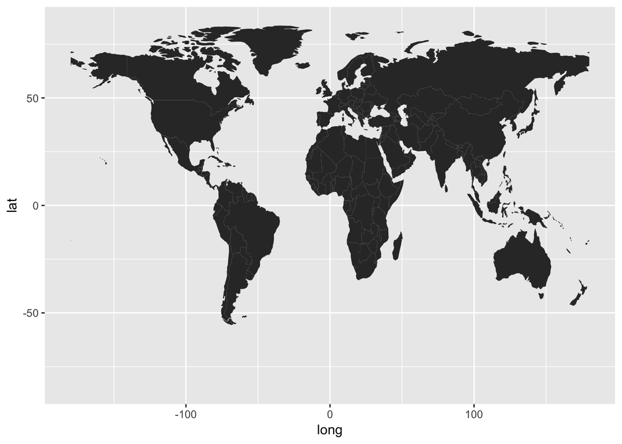

```r
ggplot(world_map2, mapping = aes(x = long, y = lat, group = group)) +
  geom_polygon() +
  coord_cartesian(xlim = c(-180, 180), ylim = c(-84, 84))
```

```r
# Here is an idea of how our group wants to map our data.  The goal is to join our data with the "world_map" data.frame.  This should provide us with a colored legened and a color map.
```